# Exploratory analysis of a GEO dataset

Ferriol Calvet

May 15, 2019

# Introduction

This exercise and all the code will be available in the following link: https://github.com/FerriolCalvet/Calvet_Ferriol-OmicsTechniques

## Summary

The following description was given: *Nebulin is a giant filamentous protein that is coextensive with the actin filaments of the skeletal muscle sarcomere. Nebulin mutations are the main cause of nemaline myopathy (NEM), with typical NEM adult patients having low expression of nebulin, yet the roles of nebulin in adult muscle remain poorly understood. To establish nebulin’s functional roles in adult muscle we performed studies on a novel conditional nebulin KO (Neb cKO) mouse model in which nebulin deletion was driven by the muscle creatine kinase (MCK) promotor. Neb cKO mice are born with high nebulin levels in their skeletal muscle but within weeks after birth nebulin expression rapidly falls to barely detectable levels Surprisingly, a large fraction of the mice survives to adulthood with low nebulin levels (<5% of control), contain nemaline rods, and undergo fiber-type switching towards oxidative types. These microarrays investigate the changes in gene expression when nebulin is deficient.*

## Experimental design

Two skeletal muscle groups were studied: Quadriceps (which is markedly smaller in the Neb cKO mice relative to control) and Soleus (which is not significantly smaller in the Neb cKO relative to control). Six biological replicates for each muscle group were selected; all are age-matched males.

## Citation(s)

This data was published in: *Li F, Buck D, De Winter J, Kolb J et al. Nebulin deficiency in adult muscle causes sarcomere defects and muscle-type-dependent changes in trophicity: novel insights in nemaline myopathy. Hum Mol Genet 2015 Sep 15;24(18):5219-33. PMID: 26123491*

## Data description

We have two files: Expression matrix, saved as *expres2* Targets’ information, saved as *targets_info*

```r
expres2 <- read.delim("expres2.txt", row.names=1)
targets_info <- read.table("targets.txt", header = T)
targets_info$group <- c(rep("1",6), rep("2",6), rep("3",6), rep("4",6))
# View(expres2)
show(targets_info)
```

```
##    sampleName muscle genotype replicate group
## 1  GSM1720833   quad  control         1     1
## 2  GSM1720834   quad  control         2     1
## 3  GSM1720835   quad  control         3     1
## 4  GSM1720836   quad  control         4     1
## 5  GSM1720837   quad  control         5     1
## 6  GSM1720838   quad  control         6     1
## 7  GSM1720839   quad      cKO         1     2
## 8  GSM1720840   quad      cKO         2     2
## 9  GSM1720841   quad      cKO         3     2
## 10 GSM1720842   quad      cKO         4     2
## 11 GSM1720843   quad      cKO         5     2
## 12 GSM1720844   quad      cKO         6     2
## 13 GSM1720845 soleus  control         1     3
## 14 GSM1720846 soleus  control         2     3
## 15 GSM1720847 soleus  control         3     3
## 16 GSM1720848 soleus  control         4     3
## 17 GSM1720849 soleus  control         5     3
## 18 GSM1720850 soleus  control         6     3
## 19 GSM1720851 soleus      cKO         1     4
## 20 GSM1720852 soleus      cKO         2     4
## 21 GSM1720853 soleus      cKO         3     4
## 22 GSM1720854 soleus      cKO         4     4
## 23 GSM1720855 soleus      cKO         5     4
## 24 GSM1720856 soleus      cKO         6     4
```

The expression matrix contains the different 24 samples in the columns. These samples can be grouped into 4 different groups, with 6 replicates per each group. Note that in the output of the previous chunk you can see these different groups and replicates. Then for each of the samples we can find 35557 observations, this means that we have information for the expression of 35557 different transcripts.

### Change sample names to informative names

This is optional, we can keep working with the original names

```r
# new_names <- paste(targets_info$muscle, targets_info$genotype, targets_info$replicate)

# colnames(expres2) <- new_names
# colnames(expres2)

# head(expres2)
```

## Analysis: Observation and summary

```r
summary(expres2)
```

```
##    GSM1720833          GSM1720834         GSM1720835
##  Min.   :    1.926   Min.   :   2.056   Min.   :   1.976
##  1st Qu.:    9.879   1st Qu.:   9.513   1st Qu.:   9.552
##  Median :   28.735   Median :  27.550   Median :  27.474
##  Mean   :  155.988   Mean   : 159.426   Mean   : 158.321
##  3rd Qu.:  102.087   3rd Qu.: 104.429   3rd Qu.: 105.798
##  Max.   :10074.650   Max.   :9715.649   Max.   :9964.478
##    GSM1720836         GSM1720837         GSM1720838
##  Min.   :   2.091   Min.   :   2.053   Min.   :   1.763
##  1st Qu.:  10.589   1st Qu.:   9.466   1st Qu.:   9.618
##  Median :  29.087   Median :  27.314   Median :  27.141
##  Mean   : 155.119   Mean   : 158.152   Mean   : 159.111
##  3rd Qu.:  99.406   3rd Qu.: 105.461   3rd Qu.: 109.799
##  Max.   :9868.282   Max.   :9775.226   Max.   :9921.328
##    GSM1720839         GSM1720840         GSM1720841
##  Min.   :   1.931   Min.   :   2.050   Min.   :   2.056
##  1st Qu.:   9.551   1st Qu.:   9.415   1st Qu.:  10.035
##  Median :  28.152   Median :  27.686   Median :  29.193
##  Mean   : 159.819   Mean   : 159.105   Mean   : 157.340
##  3rd Qu.: 109.039   3rd Qu.: 110.448   3rd Qu.: 105.951
##  Max.   :9582.167   Max.   :9381.088   Max.   :9416.265
##    GSM1720842         GSM1720843         GSM1720844
##  Min.   :   1.987   Min.   :   1.931   Min.   :   2.008
##  1st Qu.:   9.226   1st Qu.:   9.689   1st Qu.:   9.495
##  Median :  26.759   Median :  28.296   Median :  27.871
##  Mean   : 162.665   Mean   : 160.934   Mean   : 159.455
##  3rd Qu.: 115.308   3rd Qu.: 112.439   3rd Qu.: 110.487
##  Max.   :9625.813   Max.   :9710.430   Max.   :9579.855
##    GSM1720845         GSM1720846          GSM1720847
##  Min.   :   1.922   Min.   :    1.926   Min.   :   2.041
##  1st Qu.:  10.419   1st Qu.:   10.475   1st Qu.:  10.357
##  Median :  30.645   Median :   30.032   Median :  29.901
##  Mean   : 150.627   Mean   :  152.111   Mean   : 151.949
##  3rd Qu.:  98.449   3rd Qu.:  101.789   3rd Qu.: 100.777
##  Max.   :9605.822   Max.   :10044.250   Max.   :9578.962
##    GSM1720848         GSM1720849          GSM1720850
##  Min.   :   1.958   Min.   :    2.037   Min.   :   2.051
##  1st Qu.:  10.531   1st Qu.:   10.338   1st Qu.:  10.104
##  Median :  30.245   Median :   29.739   Median :  29.486
##  Mean   : 150.506   Mean   :  152.917   Mean   : 154.519
##  3rd Qu.: 100.575   3rd Qu.:  103.032   3rd Qu.: 102.257
##  Max.   :9944.322   Max.   :10034.910   Max.   :9683.776
##    GSM1720851         GSM1720852         GSM1720853
##  Min.   :   1.945   Min.   :   2.071   Min.   :   1.953
##  1st Qu.:  10.001   1st Qu.:   9.917   1st Qu.:  10.126
##  Median :  29.723   Median :  28.990   Median :  29.686
##  Mean   : 157.437   Mean   : 156.721   Mean   : 155.242
##  3rd Qu.: 102.035   3rd Qu.: 103.365   3rd Qu.: 102.394
##  Max.   :9992.598   Max.   :9708.658   Max.   :9782.025
##    GSM1720854         GSM1720855         GSM1720856
##  Min.   :   2.111   Min.   :   2.046   Min.   :   2.031
##  1st Qu.:  10.115   1st Qu.:   9.936   1st Qu.:   9.804
##  Median :  29.666   Median :  29.178   Median :  28.247
##  Mean   : 157.486   Mean   : 158.194   Mean   : 156.724
##  3rd Qu.: 103.820   3rd Qu.: 105.378   3rd Qu.: 105.078
##  Max.   :9860.875   Max.   :9730.046   Max.   :9449.606
```

If we look at the summary results, we see that the values vary a lot among the same sample. We can see that the difference between the minimum and the maximum is of the order of magnitude 4, being in most of the cases from around 2 until around 10000.  
Then the mean never falls inside the interquantile range, as this measurement is highly affected by extreme values, maybe we should correct this at some point. In order to have a clearer view of the distribution of our data, we will now make some boxplots.

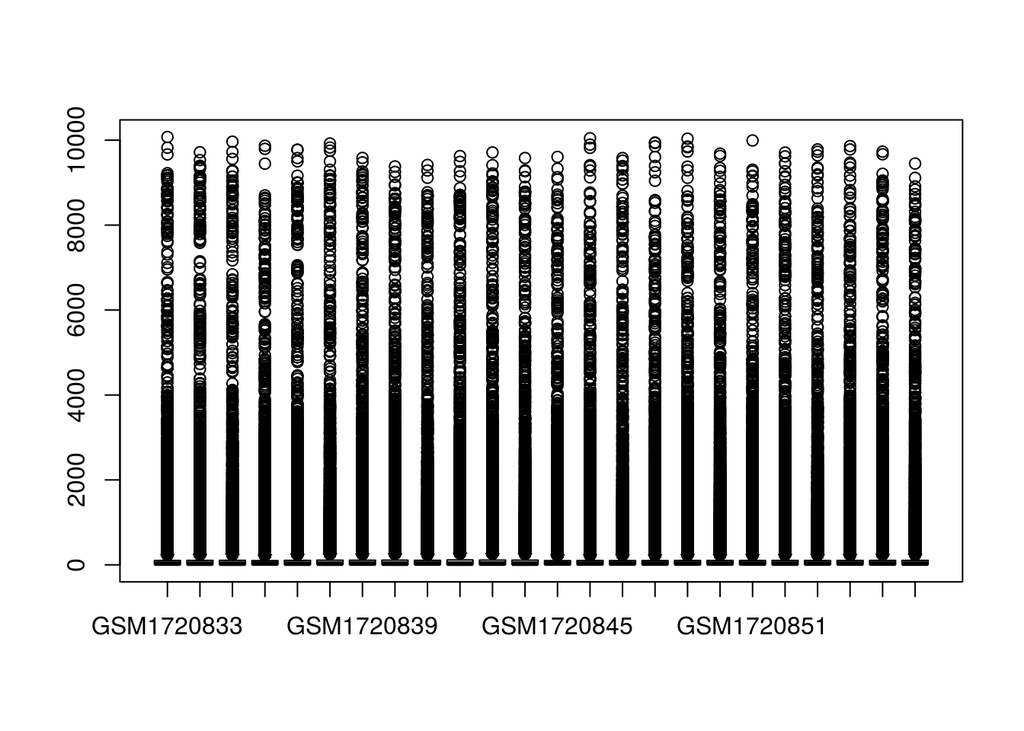

```r
boxplot(expres2)
```

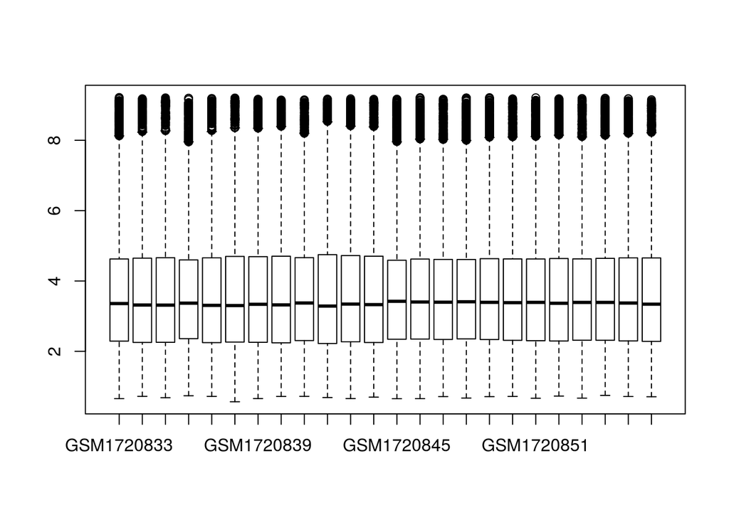

```r
# we apply log transformation because it is a possible way to correct the data
boxplot(log(expres2))
```

```r
expres2 <- log(expres2)
```

When we make the first boxplot, we can see check that yes, the data is very dispersed so we cannot appreciate any box, a possible transformation that can be applied to our data is the logarithmic transformation. If we compare the two boxplots, we can see that after the transformation the information of the different groups can be compared easily and with more balanced values.

##### Now start with the real analysis

After applying the logarithm transformation to our, we can follow with the analysis.

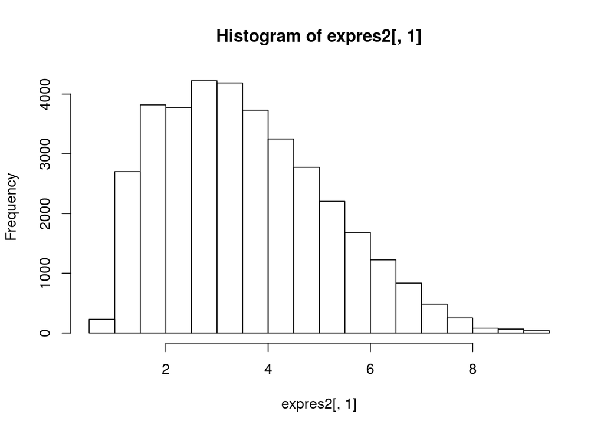

```r
hist(expres2[,1])
```

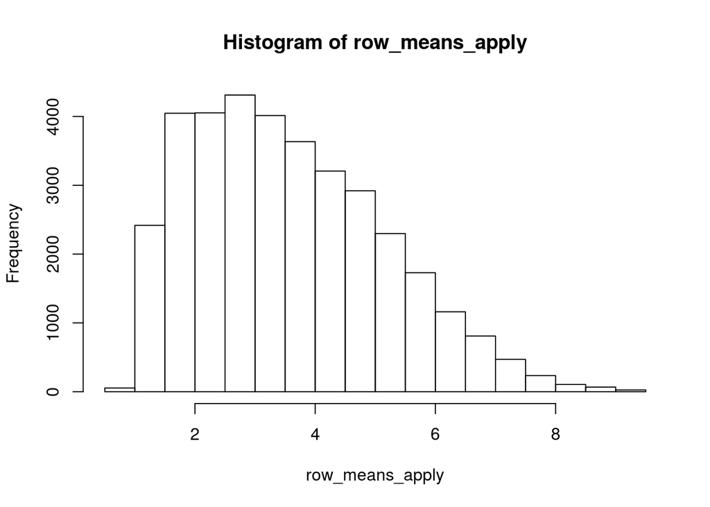

```r
row_means_apply <- apply(expres2,1, mean)
hist(row_means_apply)
```

```r
expres2 <- read.delim("expres2.txt", row.names=1)
pcs <- prcomp(expres2)
names(pcs)
```

```
## [1] "sdev"     "rotation" "center"   "scale"    "x"
```

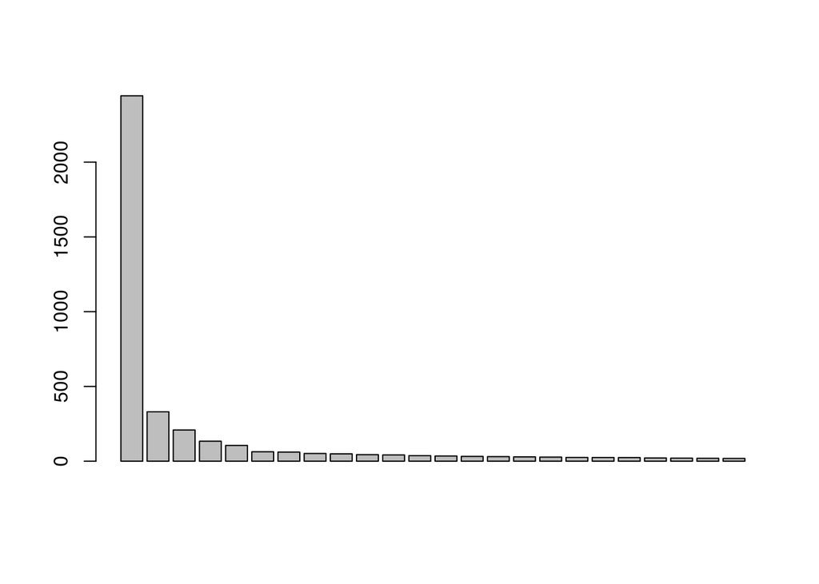

```r
barplot(pcs$sdev)
```

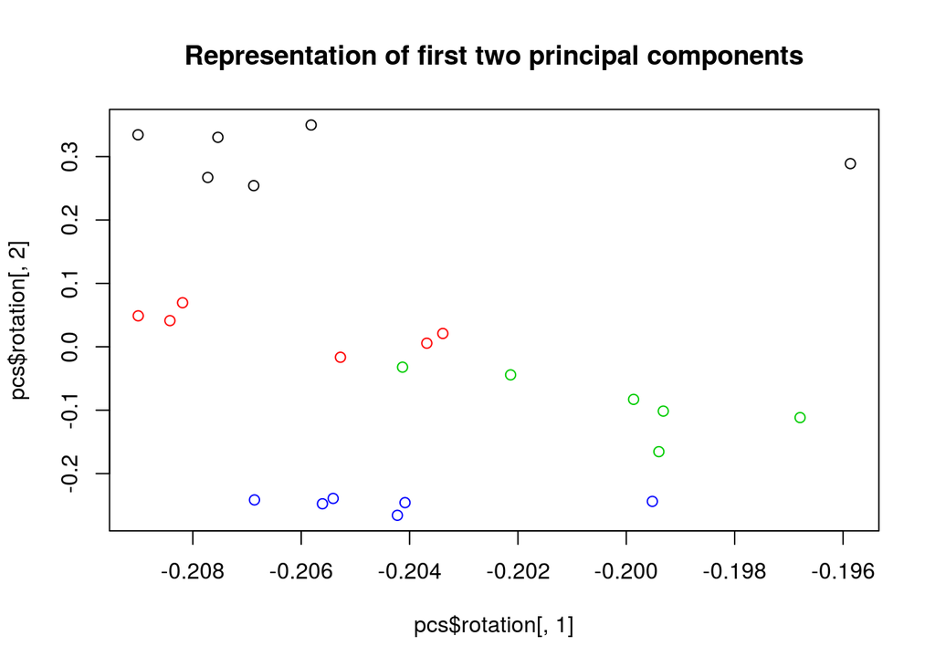

```r
plot(pcs$rotation[,1], pcs$rotation[,2], col=targets_info$group, main="Representation of first two principal components")
```

# ExpressionSet construction 1

```r
targets_column_names <- data.frame(labelDescription= colnames(targets_info))

## ----simulateInfo--------------------------------------------------------
myInfo=list(myName="Ferriol Calvet", myLab="Bioinformatics Lab",
            myContact="ferriol.calvet@alum.esci.upf.edu", myTitle="Practical Exercise on ExpressionSets")
show(myInfo)
```

```
## $myName
## [1] "Ferriol Calvet"
##
## $myLab
## [1] "Bioinformatics Lab"
##
## $myContact
## [1] "ferriol.calvet@alum.esci.upf.edu"
##
## $myTitle
## [1] "Practical Exercise on ExpressionSets"
```

```r
## ----creaExpressionSet1--------------------------------------------------
define_matrix <- as.matrix(expres2)
myEset <- ExpressionSet(define_matrix)
class(myEset)
```

```
## [1] "ExpressionSet"
## attr(,"package")
## [1] "Biobase"
```

```r
show(myEset)
```

```
## ExpressionSet (storageMode: lockedEnvironment)
## assayData: 35557 features, 24 samples
##   element names: exprs
## protocolData: none
## phenoData: none
## featureData: none
## experimentData: use 'experimentData(object)'
## Annotation:
```

```r
## ----AnnotatedDataFrame2-------------------------------------------------
columnDesc <-  data.frame(labelDescription= colnames(targets_info))
rownames(targets_info) <- targets_info$sampleName

myAnnotDF <- new("AnnotatedDataFrame", data=targets_info, varMetadata= columnDesc)
show(myAnnotDF)
```

```
## An object of class 'AnnotatedDataFrame'
##   rowNames: GSM1720833 GSM1720834 ... GSM1720856 (24 total)
##   varLabels: sampleName muscle ... group (5 total)
##   varMetadata: labelDescription
```

```r
# Version 1
phenoData(myEset) <- myAnnotDF
show(myEset)
```

```
## ExpressionSet (storageMode: lockedEnvironment)
## assayData: 35557 features, 24 samples
##   element names: exprs
## protocolData: none
## phenoData
##   rowNames: GSM1720833 GSM1720834 ... GSM1720856 (24 total)
##   varLabels: sampleName muscle ... group (5 total)
##   varMetadata: labelDescription
## featureData: none
## experimentData: use 'experimentData(object)'
## Annotation:
```

```r
# Version 2
myEset <- ExpressionSet(assayData=define_matrix, phenoData=myAnnotDF)
show(myEset)
```

```
## ExpressionSet (storageMode: lockedEnvironment)
## assayData: 35557 features, 24 samples
##   element names: exprs
## protocolData: none
## phenoData
##   sampleNames: GSM1720833 GSM1720834 ... GSM1720856 (24 total)
##   varLabels: sampleName muscle ... group (5 total)
##   varMetadata: labelDescription
## featureData: none
## experimentData: use 'experimentData(object)'
## Annotation:
```

```r
## -----add-features-names----------------------------------------------------------------
myGenes <- rownames(expres2)
myEset <- ExpressionSet(assayData=define_matrix,
                        phenoData=myAnnotDF,
                        featureNames =myGenes)

myInfo=list(myName="Ferriol Calvet", myLab="Bioinformatics Lab",
            myContact="ferriol.calvet@alum.esci.upf.edu", myTitle="Practical Exercise on ExpressionSets")

## ----label=MIAME---------------------------------------------------------
myDesc <- new("MIAME", name= myInfo[["myName"]],
              lab= myInfo[["myLab"]],
              contact= myInfo[["myContact"]] ,
              title=myInfo[["myTitle"]])

## ------------------------------------------------------------------------
myEset <- ExpressionSet(assayData=define_matrix,
                        phenoData=myAnnotDF,
                        fetureNames =myGenes,
                        experimentData = myDesc)
```

# Analyze this ExpressionSet built manually

```r
dim(exprs(myEset))
```

```
## [1] 35557    24
```

```r
class(phenoData(myEset))
```

```
## [1] "AnnotatedDataFrame"
## attr(,"package")
## [1] "Biobase"
```

```r
# This two instructions are the same
class(pData(phenoData(myEset)))
```

```
## [1] "data.frame"
```

```r
head(pData(phenoData(myEset)))
```

```
##            sampleName muscle genotype replicate group
## GSM1720833 GSM1720833   quad  control         1     1
## GSM1720834 GSM1720834   quad  control         2     1
## GSM1720835 GSM1720835   quad  control         3     1
## GSM1720836 GSM1720836   quad  control         4     1
## GSM1720837 GSM1720837   quad  control         5     1
## GSM1720838 GSM1720838   quad  control         6     1
```

```r
class(pData(myEset))
```

```
## [1] "data.frame"
```

```r
head(pData(myEset))
```

```
##            sampleName muscle genotype replicate group
## GSM1720833 GSM1720833   quad  control         1     1
## GSM1720834 GSM1720834   quad  control         2     1
## GSM1720835 GSM1720835   quad  control         3     1
## GSM1720836 GSM1720836   quad  control         4     1
## GSM1720837 GSM1720837   quad  control         5     1
## GSM1720838 GSM1720838   quad  control         6     1
```

```r
## ------------------------------------------------------------------------
smallEset <- myEset[1:50,13:24]

dim(exprs(smallEset))
```

```
## [1] 50 12
```

```r
dim(pData(smallEset))
```

```
## [1] 12  5
```

```r
head(pData(smallEset))
```

```
##            sampleName muscle genotype replicate group
## GSM1720845 GSM1720845 soleus  control         1     3
## GSM1720846 GSM1720846 soleus  control         2     3
## GSM1720847 GSM1720847 soleus  control         3     3
## GSM1720848 GSM1720848 soleus  control         4     3
## GSM1720849 GSM1720849 soleus  control         5     3
## GSM1720850 GSM1720850 soleus  control         6     3
```

```r
all(colnames(exprs(smallEset))==rownames(pData(smallEset)))
```

```
## [1] TRUE
```

For example we can select a small dataset of only two groups, in this case both selected groups are the ones with expression data of the soleus muscle. And then in the amount of genes, we have only selected the first 50 genes.

# ExpressionSet construction 2

```r
gse <- getGEO("GSE70213")
```

```
## Found 1 file(s)
```

```
## GSE70213_series_matrix.txt.gz
```

```
## File stored at:
```

```
## /tmp/RtmpZ1GtUG/GPL6246.soft
```

```r
class(gse)
```

```
## [1] "list"
```

```r
names(gse)
```

```
## [1] "GSE70213_series_matrix.txt.gz"
```

```r
gse[[1]]
```

```
## ExpressionSet (storageMode: lockedEnvironment)
## assayData: 35557 features, 24 samples
##   element names: exprs
## protocolData: none
## phenoData
##   sampleNames: GSM1720833 GSM1720834 ... GSM1720856 (24 total)
##   varLabels: title geo_accession ... tissue:ch1 (39 total)
##   varMetadata: labelDescription
## featureData
##   featureNames: 10338001 10338002 ... 10608724 (35557 total)
##   fvarLabels: ID GB_LIST ... category (12 total)
##   fvarMetadata: Column Description labelDescription
## experimentData: use 'experimentData(object)'
##   pubMedIds: 26123491
## Annotation: GPL6246
```

```r
esetFromGEO <- gse[[1]]
```

# Analyze this ExpressionSet automatically generated

```r
## ------------------------------------------------------------------------
dim(exprs(myEset))
```

```
## [1] 35557    24
```

```r
class(phenoData(myEset))
```

```
## [1] "AnnotatedDataFrame"
## attr(,"package")
## [1] "Biobase"
```

```r
# This two instructions are the same
class(pData(phenoData(myEset)))
```

```
## [1] "data.frame"
```

```r
head(pData(phenoData(myEset)))
```

```
##            sampleName muscle genotype replicate group
## GSM1720833 GSM1720833   quad  control         1     1
## GSM1720834 GSM1720834   quad  control         2     1
## GSM1720835 GSM1720835   quad  control         3     1
## GSM1720836 GSM1720836   quad  control         4     1
## GSM1720837 GSM1720837   quad  control         5     1
## GSM1720838 GSM1720838   quad  control         6     1
```

```r
class(pData(myEset))
```

```
## [1] "data.frame"
```

```r
head(pData(myEset))
```

```
##            sampleName muscle genotype replicate group
## GSM1720833 GSM1720833   quad  control         1     1
## GSM1720834 GSM1720834   quad  control         2     1
## GSM1720835 GSM1720835   quad  control         3     1
## GSM1720836 GSM1720836   quad  control         4     1
## GSM1720837 GSM1720837   quad  control         5     1
## GSM1720838 GSM1720838   quad  control         6     1
```

```r
## ------------------------------------------------------------------------
smallEset <- myEset[1:50,13:24]

dim(exprs(smallEset))
```

```
## [1] 50 12
```

```r
dim(pData(smallEset))
```

```
## [1] 12  5
```

```r
head(pData(smallEset))
```

```
##            sampleName muscle genotype replicate group
## GSM1720845 GSM1720845 soleus  control         1     3
## GSM1720846 GSM1720846 soleus  control         2     3
## GSM1720847 GSM1720847 soleus  control         3     3
## GSM1720848 GSM1720848 soleus  control         4     3
## GSM1720849 GSM1720849 soleus  control         5     3
## GSM1720850 GSM1720850 soleus  control         6     3
```

```r
all(colnames(exprs(smallEset))==rownames(pData(smallEset)))
```

```
## [1] TRUE
```

We can see that now the results are the same as before.